# Lab 4 Exercises

```r
forwardDifference <- function(f=function(x) 0,
                              u0=function(x) 2*sin(2*pi*x),
                              K=1, L=1, N=30, T=0.1, M=200) {
    # set up space grid
    h <- L/N
    x <- h*(1:(N-1))

    # set up time grid
    tau <- T/M
    t <- tau*(0:M)

    # set up vectors with initial condition and inhomogenous term
    w <- u0(x)
    F <- f(x)

    # Set up evolution matrix
    gamma <- K*tau/(h^2)
    A <- diag(1-2*gamma, N-1)
    for (k in 1:(N-2)) {
        A[k,k+1] <- gamma
        A[k+1,k] <- gamma
    }

    Temperature <- matrix(0, N-1, M+1)  # Matrix to hold the solution
    Temperature[ , 1] <- w  # Initial value
    # Loop over time steps
    for (j in 1:M) {
        w <- A %*% w + tau * F
        Temperature[ , j+1] <- w
    }

    # Return a list consisting of time grid, x grid and solution
    return(list(x=x, t=t, w=Temperature))
}
library(plot3Drgl)
```

## Exercise 1

Use the function `forwardDifference()` to solve the equation
$$u_{t}(x,t) = \frac14 u_{xx}(x,t)-16\sin(8\pi x), \quad
0<x< 1, \quad 0<t<0.2$$
with initial condition
$$u(0, t) = u(1, t)=0, \quad u(x, 0) = \sin(\pi x).$$
Plot the solution.

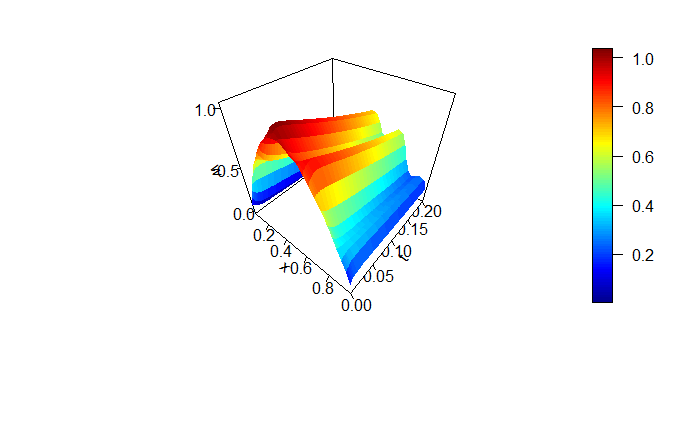

`r`r plotrgl(smooth=TRUE, lighting = TRUE)

## Exercise 2

Determine the maximal error when you use a step-size of $h=1/120$. Keep on doubling the number of steps in the $x$ directions. Does the error continue to decrease as expected? What happens to the running time of the code?

For convenince I first encapsulate the code for calculating the maximal error into a function so that we can then easily call it with different step sizes.

```r
# numerical solution
numSol <- forwardDifference(f=function(x) {-25*sin(3*pi*x)},
                     u0=function(x) {-3/2*sin(2*pi*x)},
                     T=T, M=M, N=N)
# exact solution
x <- numSol$x
t <- numSol$t
xy <- mesh(x, t)
u <- with(xy, -3/2*sin(2*pi*x)*exp(-4*pi^2*y)
                   -25/(9*pi^2)*sin(3*pi*x)*(1-exp(-9*pi^2*y)))

return(max(abs(u - numSol$w)))
```

With h=1/120 we obtain a maximum error of

`r`r maxError(1/120)

```
[1] 0.0004321074
```

`r`r maxError(1/240)

```
[1] 0.0001080362
```

Another improvement by a factor of 1/4 but also a marked increase in runtime.

## Exercise 3

Similarly calculate the maximal error in the numerical solution from exercise 1, again for a range of step-sizes.

The exact solution of the problem in exercise 1 is
$$u(x,t) = \sin(\pi x)e^{-\pi^2 t}
-\frac{1}{4\pi^2}\sin(8\pi x)\left(1-e^{-64\pi^2 t}\right).$$
We modify the function `maxError()` appropriately to reflect the new problem.

```r
# numerical solution
numSol <- forwardDifference(f=function(x) -16*sin(8*pi*x),
                         u0=function(x) sin(pi*x),
                         K=K, T=T, M=M, N=N)
# exact solution
x <- numSol$x
t <- numSol$t
xy <- mesh(x, t)
u <- with(xy, sin(pi*x)*exp(-pi^2*y)
                   -1/(4*pi^2)*sin(8*pi*x)*(1-exp(-64*pi^2*y)))

return(max(abs(u - numSol$w)))
```

`r`r maxError(1/30)

```
[1] 0.00239827
```

`r`r maxError(1/60)

```
[1] 0.0005555315
```

`r`r maxError(1/120)

```
[1] 0.0001365421
```

`r`r maxError(1/240)

```
[1] 3.417537e-05
```

## Exercise 4 (Challenge)

Write code that produces a plot of the maximal error against the number of steps $M$.

`r`r h <- 1/(30*2^(0:3)) error <- sapply(sizes, maxError) plot(h, error)

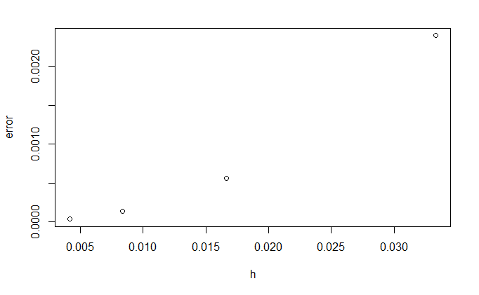

`r`r plot(log(h), log(error)) abline(lm(log(error) ~ log(h)))

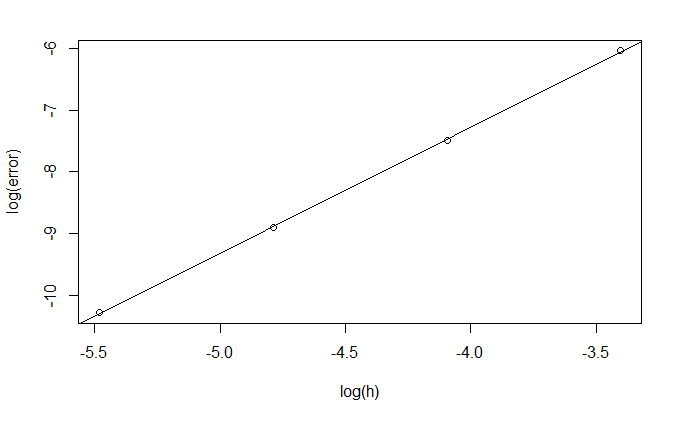

`r`r summary(lm(log(error) ~ log(h)))

```
Call:
lm(formula = log(error) ~ log(h))

Residuals:
       1        2        3        4
 0.02142 -0.02553 -0.01319  0.01731

Coefficients:
            Estimate Std. Error t value Pr(>|t|)
(Intercept)  0.89191    0.08186    10.9  0.00832 **
log(h)       2.04232    0.01816   112.5  7.9e-05 ***
---
Signif. codes:  0 â€˜***â€™ 0.001 â€˜**â€™ 0.01 â€˜*â€™ 0.05 â€˜.â€™ 0.1 â€˜ â€™ 1

Residual standard error: 0.02814 on 2 degrees of freedom
Multiple R-squared:  0.9998,    Adjusted R-squared:  0.9998
F-statistic: 1.265e+04 on 1 and 2 DF,  p-value: 7.904e-05
```